# Estimating cone fundamentals from color matching functions

We show how to use the color matching functions from dichromatic subjects to estimate the cone fundamentals.

The assumptions are these.

1. Dichromats and color normals have the same cones, with each of the three types of dichromats missing one of the three types of cones
2. The color matching functions are a linear transformation away from the cone fundamentals

The insight is to use some geometry and linear algebra as follows. Suppose that the three cone fundamentals of a normal are C = [L,M,S]. The fundamentals for a protanope are [M,S], for a deuteranope is [L,S] and for a tritanope is [L,M].

Notice that the color-matching functions of the deuteranopes are spanned by only two vectors; thus they form a plane in wavelength-space. I can't plot all the dimensions for wavelength, but intuitively we can show the plane for, say, a deuteranope and the plane for a tritanope.

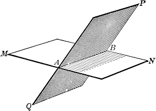

The deuteranope ([L,S], and tritanope ([L,M]) share one dimension, the L-cone dimension. So the intersection of the two planes must be the L-cone fundamental. Similarly, we can compare the other dichromatic combinations to estimate all three cone types.

One of the more surprising aspects of the calculation is that we can do this calculation from the color matching functions, without knowing any of the fundamentals. This is because the color-matching functions span the same plane as the cone fundamentals. So, knowing only the color-matching functions we can compute all three color fundamentals. Very cool!

## Read in the fundamentals

Read the standard cone fundamentals compiled by Andrew Stockman.

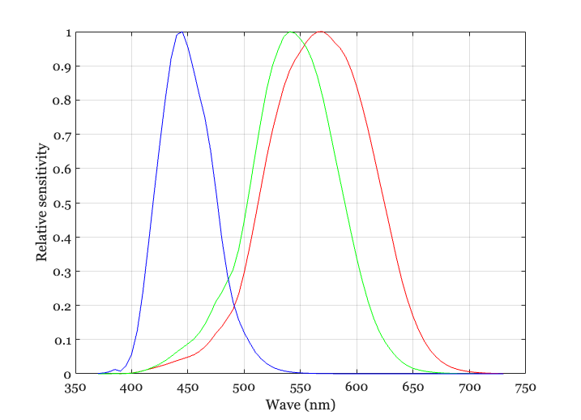

```matlab
[stockman,wave] = ieReadSpectra('StockmanEnergy');

ieNewGraphWin;
plot(wave,stockman);
xlabel('Wave (nm)'); ylabel('Relative sensitivity'); grid on
```

## Simulated CMFs for the three types of dichromats

We apply a linear transform to the protan/deutan/tritan fundamentals to simulate the CMFs. Notice that we use a different linear transform for each of the deuteranopic CMFs. Even so, the calculation still solves.

```matlab
L = rand(2,2);
M = rand(2,2);
N = rand(2,2);

% We check that L,M and N are invertible
assert(max2(L\L - eye(2)) < 1e-10)
assert(max2(M\M - eye(2)) < 1e-10)
assert(max2(N\N - eye(2)) < 1e-10)

% These are the synthetic CMFs of the three types of deuteranopes
protan = stockman(:,2:3)*L;
deutan = stockman(:,[1,3])*M;
tritan = stockman(:,1:2)*N;
```

## The intersection of planes

We solve for the intersection of the two planes using this simple linear algebraic trick.

For this vector, the weighted sum of the first two columns (the weights are (1,2)) must be the negative of the weighted sum of the third and fourth columns (n(3,4)). That vector is in the intersection of the two planes!

We find the solution to the equation from the singular value decomposition.

### L-Cone

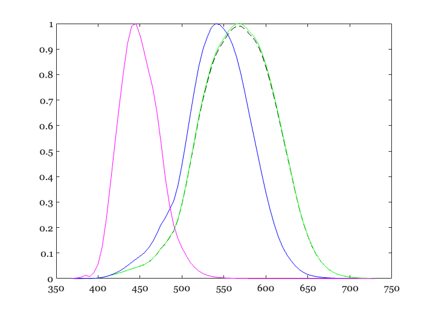

```matlab
X = [deutan,tritan];  % L-cone
[U,~,~] = svd(X'*X);
n = U(:,4);
est = X(:,[1,2])*n(1:2);

% Make the estimate positive
if sum(est) < 0, est = -1*est; end
est = ieScale(est,1);

%{
% Check that the sum of the third and fourth is the same (up to sign) this way
 est2 = X(:,[3,4])*n(3:4);
 if sum(est2) < 0, est = -1*est2; end
 est2 = ieScale(est2,1);
 ieNewGraphWin, plot(est(:),est2(:),'.');
 identityLine;
%}

% Plot the estimate and compare with the original
% The 0.99 makes the overlay visible
ieNewGraphWin;
plot(wave,0.99*est,'k--',wave,stockman);
```

### M-cone

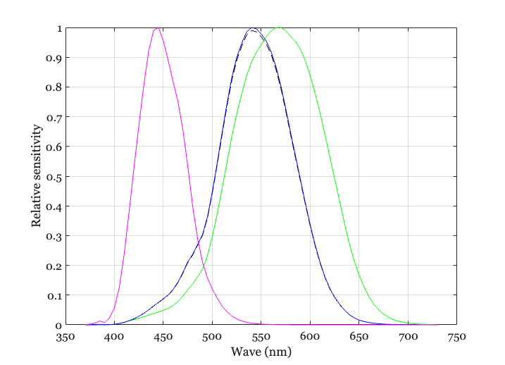

```matlab
X = [protan,tritan];  % M-cone
[U,~,~] = svd(X'*X);
n = U(:,4);
est = X(:,[1,2])*n(1:2);

% Make the estimate positive
if sum(est) < 0, est = -1*est; end
est = ieScale(est,1);
ieNewGraphWin;
plot(wave,0.99*est,'k--',wave,stockman);
xlabel('Wave (nm)'); ylabel('Relative sensitivity'); grid on;
```

### S-cone

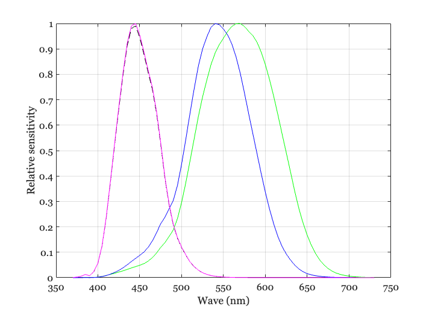

```matlab
X = [protan,deutan];
[U,~,~] = svd(X'*X);
n = U(:,4);
est = X(:,[1,2])*n(1:2);

% Make the estimate positive
if sum(est) < 0, est = -1*est; end
est = ieScale(est,1);
ieNewGraphWin;
plot(wave,0.99*est,'k--',wave,stockman);
xlabel('Wave (nm)'); ylabel('Relative sensitivity'); grid on;
```